# EDA

# Data Inputs and Preparation

## Setting up libraries

```r
library(dplyr)
library(ggplot2)
library(ggcorrplot)
library(ggpubr)
```

## Reading dataset samples

```r
dallas<-read.csv('dallas_merge.csv',header = T)
boston<-read.csv('boston_merge.csv',header = T)
denver<-read.csv('denver_merge.csv',header = T)

all <- read.csv('merge_dataset.csv', header = T)
```

We are performing EDA on a sampling of the cities. The selected cities are Dallas, Boston, and Denver. In addition, we are reviewing the full population of city data.

```r
head(dallas)
```

|  | X | id | host_is_superhost | host_total_listings_count | neighbourhood | latitude | longitude | property_type | room_type | accommodates | bathrooms | bedrooms | price | minimum_nights_avg_ntm | maximum_nights_avg_ntm | review_scores_rating | review_scores_accuracy | income |
| --- | --- | --- | --- | --- | --- | --- | --- | --- | --- | --- | --- | --- | --- | --- | --- | --- | --- | --- |
| 1 | 0 | 61878 | t | 1 | Dallas, Texas, United States | 32.81829 | -96.81893 | Entire condominium (condo) | Entire home/apt | 3 | 1.0 | 1 | 72 | 30 | 1125 | 4.75 | 4.82 | 1707 |
| 2 | 1 | 270936 | f | 2 | Dallas, Texas, United States | 32.81442 | -96.81548 | Entire condominium (condo) | Entire home/apt | 2 | 1.0 | 1 | 75 | 30 | 90 | 4.93 | 4.95 | 2325 |
| 3 | 2 | 776810 | t | 1 | Dallas, Texas, United States | 32.81304 | -96.81540 | Entire loft | Entire home/apt | 2 | 1.5 | 1 | 75 | 5 | 1125 | 4.90 | 4.89 | 1350 |
| 4 | 3 | 795703 | t | 2 | Dallas, Texas, United States | 32.80158 | -96.81117 | Entire condominium (condo) | Entire home/apt | 3 | 1.0 | 1 | 199 | 30 | 1125 | 4.84 | 4.91 | 1206 |
| 5 | 4 | 860248 | f | 4 | Dallas, Texas, United States | 32.85521 | -96.70482 | Private room in residential home | Private room | 2 | 1.0 | 1 | 38 | 3 | 365 | 4.84 | 4.82 | 92 |
| 6 | 5 | 1056850 | f | 3 | Dallas, Texas, United States | 32.82057 | -96.80932 | Entire rental unit | Entire home/apt | 2 | 1.0 | 1 | 95 | 2 | 1125 | 4.98 | 5.00 | 855 |

## Data preparation for dummy variables

```r
#Data cleansing for correlation matrix by creating dummy variables

#DALLAS
dallas1<-dallas[,-c(1,2,5,6,7,8)]

dallas1$superhost<-ifelse(dallas$host_is_superhost=='t',1,0)
dallas1$private_room<-ifelse(dallas$room_type=='Private room',1,0)
dallas1$shared_room<-ifelse(dallas$room_type=='Shared room',1,0)
dallas_roomtype<-data.frame(room_type=factor(dallas$room_type))

dallas1<-dallas1[,c(2,4,5,6,7,8,9,10,11,12,13,14,15)]
colnames(dallas1)[c(6,7,8)]<-c('min_nights','max_nights','review_scores')

#BOSTON
boston1<-boston[,-c(1,2,5,6,7,8)]

boston1$superhost<-ifelse(boston1$host_is_superhost=='t',1,0)
boston1$private_room<-ifelse(boston1$room_type=='Private room',1,0)
boston1$shared_room<-ifelse(boston1$room_type=='Shared room',1,0)
boston_roomtype<-data.frame(room_type=factor(boston1$room_type))

boston1<-boston1[,c(2,4,5,6,7,8,9,10,11,12,13,14,15)]
colnames(boston1)[c(6,7,8)]<-c('min_nights','max_nights','review_scores')

#DENVER
denver1<-denver[,-c(1,2,5,6,7,8)]

denver1$superhost<-ifelse(denver1$host_is_superhost=='t',1,0)
denver1$private_room<-ifelse(denver1$room_type=='Private room',1,0)
denver1$shared_room<-ifelse(denver1$room_type=='Shared room',1,0)
denver_roomtype<-data.frame(room_type=factor(denver1$room_type))

denver1<-denver1[,c(2,4,5,6,7,8,9,10,11,12,13,14,15)]
colnames(denver1)[c(6,7,8)]<-c('min_nights','max_nights','review_scores')

#ALL
all1<-all[,-c(1,2,5,6,7,8)]

all1$superhost<-ifelse(all1$host_is_superhost=='t',1,0)
all1$private_room<-ifelse(all1$room_type=='Private room',1,0)
all1$shared_room<-ifelse(all1$room_type=='Shared room',1,0)
all_roomtype<-data.frame(room_type=factor(all1$room_type))

all1<-all1[,c(2,4,5,6,7,8,9,10,11,12,13,14,15)]
colnames(all1)[c(6,7,8)]<-c('min_nights','max_nights','review_scores')
```

# EDA Insights

## Room type

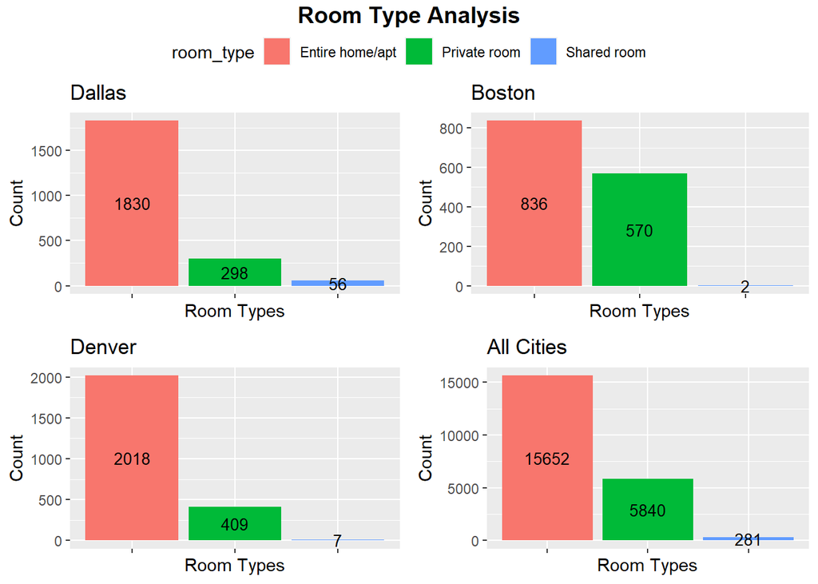

```r
dallas_room_type <- ggplot(dallas, aes(x = room_type, fill=room_type)) +
  geom_bar() + ggtitle("Dallas")+
  xlab("Room Types") + ylab("Count")+
  stat_count(geom = "text", colour = "black", size = 3.5,
  aes(label = ..count..),position=position_stack(vjust=0.5))


boston_room_type <- ggplot(boston, aes(x = room_type, fill=room_type)) +
  geom_bar() + ggtitle("Boston")+
  xlab("Room Types") + ylab("Count")+
  stat_count(geom = "text", colour = "black", size = 3.5,
  aes(label = ..count..),position=position_stack(vjust=0.5))

denver_room_type <- ggplot(denver, aes(x = room_type, fill=room_type)) +
  geom_bar() +ggtitle("Denver")+
  xlab("Room Types") + ylab("Count")+
  stat_count(geom = "text", colour = "black", size = 3.5,
  aes(label = ..count..),position=position_stack(vjust=0.5))

all_room_type <- ggplot(all, aes(x = room_type, fill=room_type)) +
  geom_bar()+ggtitle("All Cities")+
  xlab("Room Types") + ylab("Count")+
  stat_count(geom = "text", colour = "black", size = 3.5,
  aes(label = ..count..),position=position_stack(vjust=0.5))

room_type_arrange <- ggarrange(dallas_room_type+ rremove("x.text"), boston_room_type+ rremove("x.text"), denver_room_type+ rremove("x.text"), all_room_type + rremove("x.text")
          , ncol = 2, nrow = 2, common.legend = TRUE)

annotate_figure(room_type_arrange, top = text_grob("Room Type Analysis",
               color = "Black", face = "bold", size = 14))
```

Looking at the room_types, we are able to infer what types of property owners the hosts are. We would expect the listings that are private rooms or shared rooms to be from homeowners renting out spare rooms while entire home/apt is more likely to be real estate investors trying to generate more profit. It seems like some cities, such as Boston, are more accommodating to homeowners. However, the majority of Airbnb hosts are by far real estate investors. This suggests that this is a prime opportunity to investigate real estate purchases for short-term rentals.

## Correlation Plot Analysis

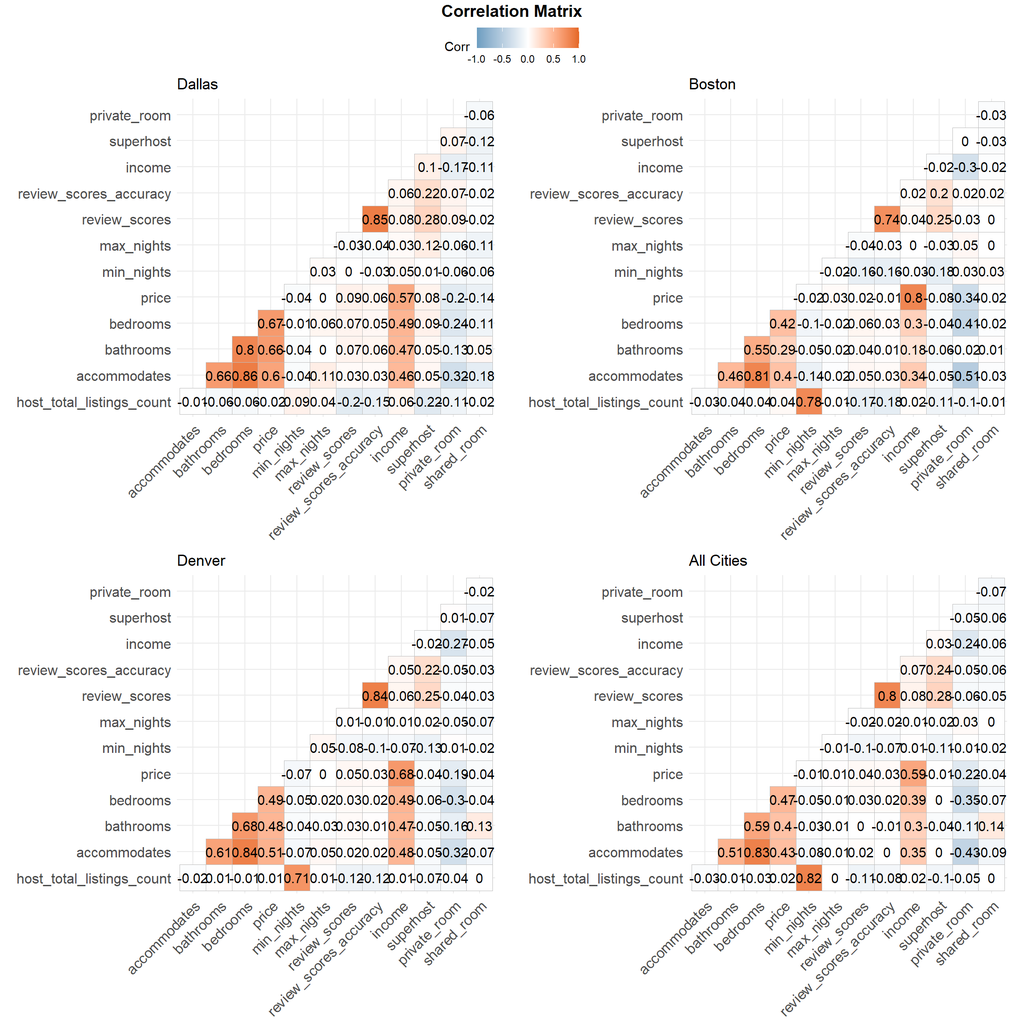

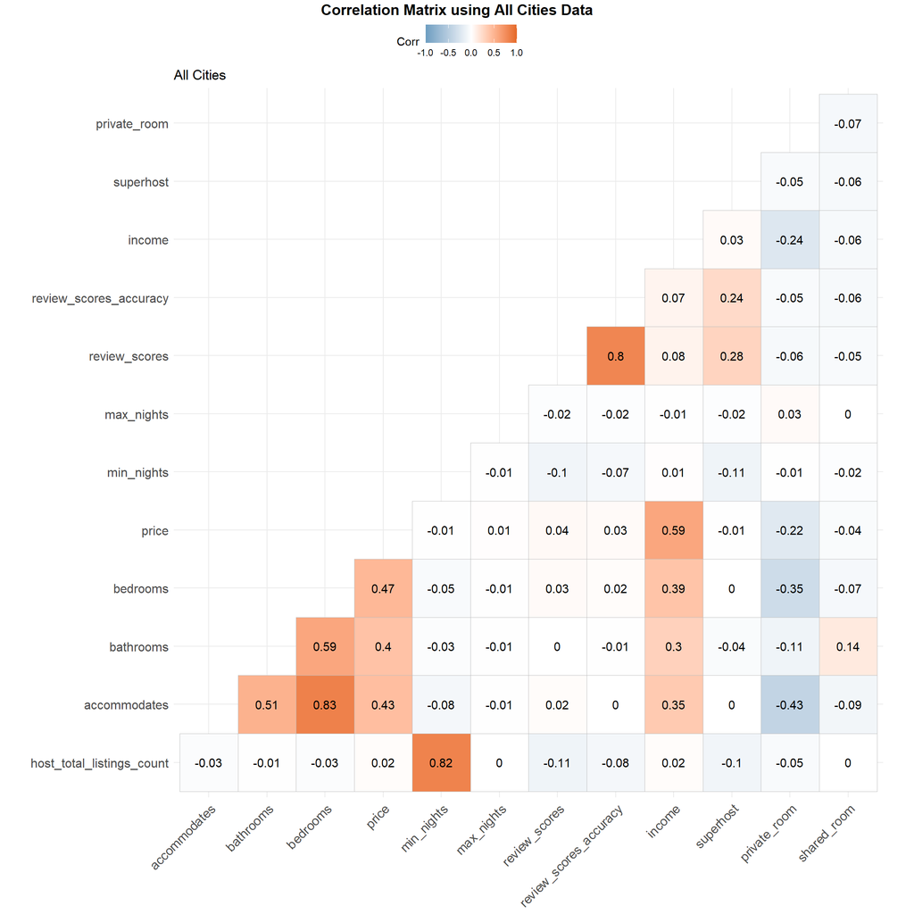

The correlation matrices provide similar results between the cities, so this analysis will focus on the All Cities matrix.

Most of the negative correlations are related to private_rooms and are in line with expectations. We would expect that listing a single room would hold less people and be associated with lower prices, resulting in less income.

## Accomodates versus price

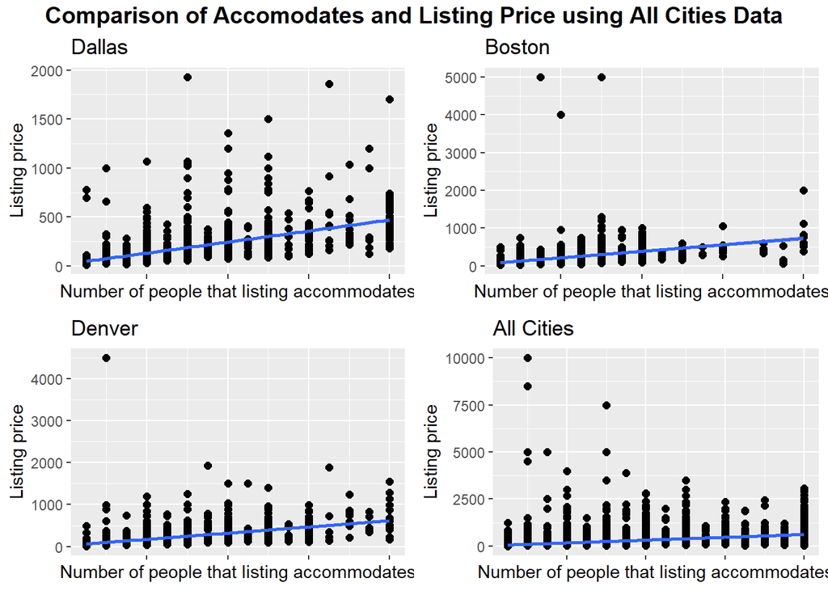

```r
dallas_accomodates_vs_price <- ggplot(dallas, aes(x=accommodates, y=price)) +
  geom_point(size=2)+
  ggtitle("Dallas")+
  xlab("Number of people that listing accommodates") + ylab("Listing price")+
  geom_smooth(method=lm)


boston_accomodates_vs_price <-ggplot(boston, aes(x=accommodates, y=price)) +
  geom_point(size=2)+
  ggtitle("Boston")+
  xlab("Number of people that listing accommodates") + ylab("Listing price")+
  geom_smooth(method=lm)


denver_accomodates_vs_price <-ggplot(denver, aes(x=accommodates, y=price)) +
  geom_point(size=2)+
  ggtitle("Denver")+
  xlab("Number of people that listing accommodates") + ylab("Listing price")+
  geom_smooth(method=lm)


all_accomodates_vs_price <- ggplot(all, aes(x=accommodates, y=price)) +
  geom_point(size=2)+
  ggtitle("All Cities")+
  xlab("Number of people that listing accommodates") + ylab("Listing price")+
  geom_smooth(method=lm)

accomodates_vs_price_arrange <- ggarrange(dallas_accomodates_vs_price+ rremove("x.text"), boston_accomodates_vs_price+ rremove("x.text"), denver_accomodates_vs_price+ rremove("x.text"), all_accomodates_vs_price + rremove("x.text")
          , ncol = 2, nrow = 2, common.legend = TRUE)
annotate_figure(accomodates_vs_price_arrange, top = text_grob("Comparison of Accomodates and Listing Price using All Cities Data",
               color = "Black", face = "bold", size = 14))
```

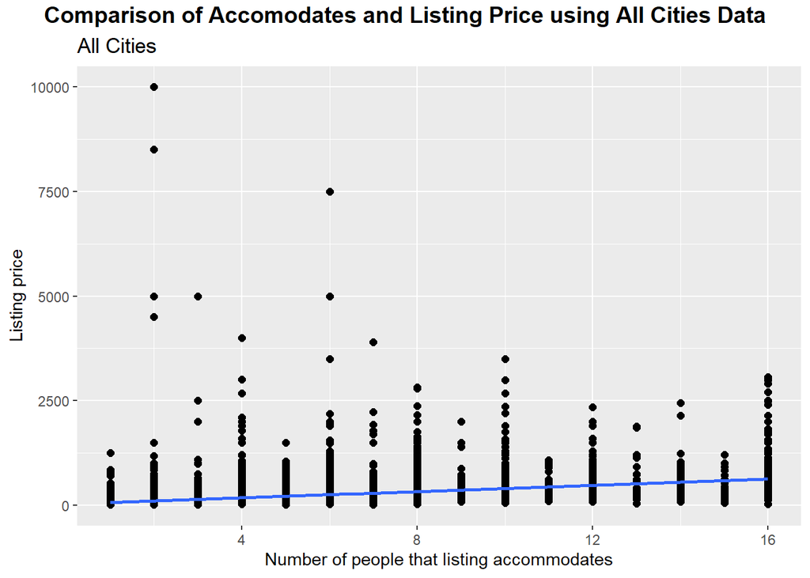

```r
accomodates_vs_price_all_arrange <- ggarrange(all_accomodates_vs_price
          , ncol = 1, nrow = 1, common.legend = TRUE)
annotate_figure(accomodates_vs_price_all_arrange, top = text_grob("Comparison of Accomodates and Listing Price using All Cities Data",
               color = "Black", face = "bold", size = 14))
```

Overall, it looks like there is increasing trend where the number of people that a listing accommodates leads to a higher listing price. Again, we see some significant outliers in terms of listing pricing where some listings are more than triple the price of similarly sized listing. This would be an interesting to explore that differentiates these types of properties whether they are in a more desirable locations or with better amenities.

## Superhost Analysis

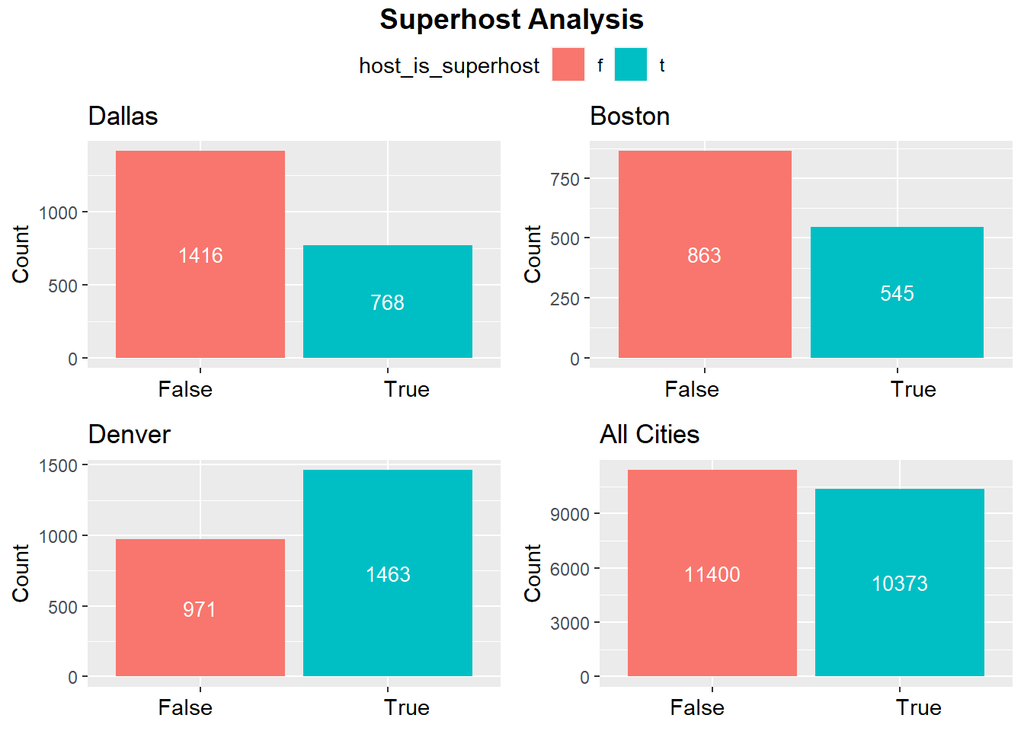

```r
dallas_super <- ggplot(dallas, aes(x = host_is_superhost, fill=host_is_superhost)) +
  geom_bar() + ggtitle("Dallas")+
  xlab("False                            True") + ylab("Count")+
  stat_count(geom = "text", colour = "white", size = 3.5,
  aes(label = ..count..),position=position_stack(vjust=0.5))

boston_super <- ggplot(boston, aes(x = host_is_superhost, fill=host_is_superhost)) +
  geom_bar() + ggtitle("Boston")+
  xlab("False                            True") + ylab("Count")+
  stat_count(geom = "text", colour = "white", size = 3.5,
  aes(label = ..count..),position=position_stack(vjust=0.5))

denver_super <- ggplot(denver, aes(x = host_is_superhost, fill=host_is_superhost)) +
  geom_bar() + ggtitle("Denver")+
  xlab("False                            True") + ylab("Count")+
  stat_count(geom = "text", colour = "white", size = 3.5,
  aes(label = ..count..),position=position_stack(vjust=0.5))


all_super <- ggplot(all, aes(x = host_is_superhost, fill=host_is_superhost)) +
  geom_bar() + ggtitle("All Cities")+
  xlab("False                            True") + ylab("Count")+
  stat_count(geom = "text", colour = "white", size = 3.5,
  aes(label = ..count..),position=position_stack(vjust=0.5))

super_arrange <- ggarrange(dallas_super+ rremove("x.text"), boston_super+ rremove("x.text"), denver_super+ rremove("x.text"), all_super + rremove("x.text")
          , ncol = 2, nrow = 2, common.legend = TRUE)
annotate_figure(super_arrange, top = text_grob("Superhost Analysis",
               color = "Black", face = "bold", size = 14))
```

Superhost is a designation from Airbnb given to hosts that met their criteria: having high overall ratings, over 10+ stays, low cancellation rates, and high response rates. Airbnb advertises Superhosts as having greater visibility and earning potential, but what we see from the data is there is significant number of superhosts throughout the platform. This varies between cities, but overall a large porportion of hosts are actually superhosts. With so many users as superhosts, the financial value of being a superhost may be diluted and may reduce any price premiums that they may previously been able to charge.